[figure not shown]

# Meta-analysis of Turkish Energy and Climate Pathways

## By Görkem Güngör and Latife Demirtaş

## Scope and feature overview

The **Türkiye National Energy Plan** (TUEP) modeling horizon is 2035 based on the net-zero target in 2053.

The **pyam** package is used for analyzing, visualizing and working with timeseries data following the format established by the *Integrated Assessment Modeling Consortium* ([IAMC](https://www.iamconsortium.org)); [read the docs](https://pyam-iamc.readthedocs.io/en/stable/data.html) for more information.

## Capacity projections

| Installed capacity | unit | 2030 | 2035 | 2055 |
| --- | --- | --- | --- | --- |
| Solar power | GW |  | 52.9 (59.7<sup>1</sup>) |  |
| Wind power | GW |  | 29.6 (50.1<sup>1</sup>) |  |
| Nuclear power | GW |  | 7.2 (4.8<sup>1</sup>) |  |
| New installed capacity | GW |  | 96.9 |  |
| Total installed capacity | GW |  | 189.7 (202.1<sup>1</sup>) |  |
| Battery storage | GW |  | 7.5 |  |
| Electrolyser | GW | 1.9 | 5.0 | 70.0 |
| Demand side management | GW | 0.9 | 1.7 |  |

<sup>1</sup> Capacity projections of Istanbul Policy Center for Net-Zero Scenario

```python
df.model
```

```
['Gungor (2020)',
 'IPC (2020)',
 'IPC (2021)',
 'MENR (2006)',
 'MENR (2023)',
 'TUBITAK (2012)']
```

```python
df.scenario
```

```
['Alternative Scenario',
 'Baseline Scenario',
 'CO2 Scenario',
 'Net-Zero Scenario',
 'Optimistic Scenario',
 'Pessimistic Scenario',
 'Reference Scenario',
 'SSP1-Baseline-FIT',
 'SSP1-RCP2.6-FIT',
 'SSP2-Baseline-FIT',
 'SSP2-RCP2.6-FIT',
 'SSP3-Baseline-FIT',
 'SSP3-RCP3.4-FIT']
```

## Visualize timeseries data using the plotting library

This section provides an illustrative example of the plotting features of the **pyam** package.

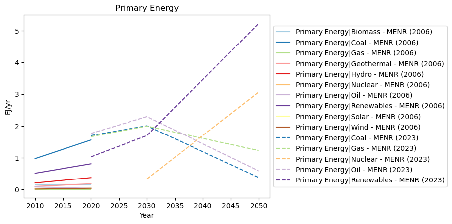

```python
%%capture --no-display
from pyam.plotting import OUTSIDE_LEGEND
cmap = 'Paired'
display_df.filter(region='Turkey').plot(title='Primary Energy',
                                        color='variable', linestyle="model", cmap=cmap, legend={"loc":"outside right"})
```

## Visualize timeseries data using the plotting library

This section provides an illustrative example of the plotting features of the **pyam** package.

In the next cell, we show a simple line plot of estimated CO2 emissions. The colours are assigned randomly by default, and **pyam** deactivates the legend if there are too many lines. The **MENR (2023)** values are taken from the [Updated 1st NDC of Turkey to the UNFCCC](https://unfccc.int/sites/default/files/NDC/2023-04/T%C3%9CRK%C4%B0YE_UPDATED%201st%20NDC_EN.pdf) and converted from CO2eq to CO2 using the factor *0.79* calculated from the average ratio between CO2 and CO2eq (excluding LULUCF) emissions in [2022 National Inventory Report of Turkey](https://unfccc.int/documents/461926).

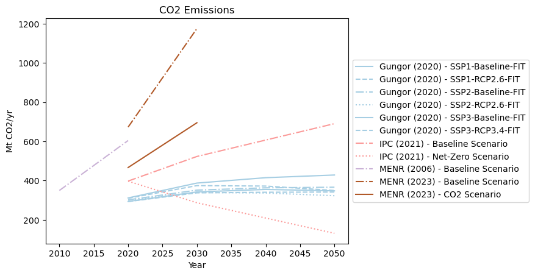

```python
%%capture --no-display
cmap = 'Paired'
df.filter(variable='Emissions|CO2', region='Turkey').plot(color='model', title='CO2 Emissions',
                                                          linestyle='scenario', cmap=cmap, legend={"loc":"outside right"})
```

### Use the `exclude_on_fail` feature to create a sub-selection of the scenario ensemble

Per default, the functions above only report how many scenarios or which data points do not satisfy the validation criteria above. However, they also have an option to `exclude_on_fail`, which marks all scenarios failing the validation as `exclude=True` in the 'meta' table. This feature can be particularly helpful when a user wants to perform a number of validation steps and then efficiently remove all scenarios violating any of the criteria as part of a scripted workflow.

We illustrate a simple validation workflow using the CO2 emissions. The next cell shows the trajectories of CO2 emissions across all scenarios.

The next two cells perform validation to exclude all scenarios that have implausibly low emissions in 2020 (i.e., unrealistic near-term behaviour) as well as those that do not reduce emissions over the modeling horizon (i.e., exceed a value of 600 MT CO2 in any year).

```python
df.validate(criteria={'Emissions|CO2': {'lo': 300, 'year': 2020}}, exclude_on_fail=True)
```

```
pyam.core - INFO: 2 of 272 data points do not satisfy the criteria
pyam.core - INFO: 2 non-valid scenarios will be excluded
```

|  | model | scenario | region | variable | unit | year | type | value |
| --- | --- | --- | --- | --- | --- | --- | --- | --- |
| 0 | Gungor (2020) | SSP1-Baseline-FIT | Turkey | Emissions\|CO2 | Mt CO2/yr | 2020 | Linear Programming | 293.826 |
| 1 | Gungor (2020) | SSP1-RCP2.6-FIT | Turkey | Emissions\|CO2 | Mt CO2/yr | 2020 | Linear Programming | 293.363 |

```python
df.validate(criteria={'Emissions|CO2': {'up': 600}}, exclude_on_fail=True)
```

```
pyam.core - INFO: 5 of 272 data points do not satisfy the criteria
pyam.core - INFO: 4 non-valid scenarios will be excluded
```

|  | model | scenario | region | variable | unit | year | type | value |
| --- | --- | --- | --- | --- | --- | --- | --- | --- |
| 0 | IPC (2021) | Baseline Scenario | Turkey | Emissions\|CO2 | Mt CO2/yr | 2050 | CGE | 690.50 |
| 1 | MENR (2006) | Baseline Scenario | Turkey | Emissions\|CO2 | Mt CO2/yr | 2020 | Market Based Simulation | 604.63 |
| 2 | MENR (2023) | Baseline Scenario | Turkey | Emissions\|CO2 | Mt CO2/yr | 2030 | Linear Programming | 1175.00 |
| 3 | MENR (2023) | Baseline Scenario | Turkey | Emissions\|CO2 | Mt CO2/yr | 2020 | Linear Programming | 673.00 |
| 4 | MENR (2023) | CO2 Scenario | Turkey | Emissions\|CO2 | Mt CO2/yr | 2030 | Linear Programming | 695.00 |

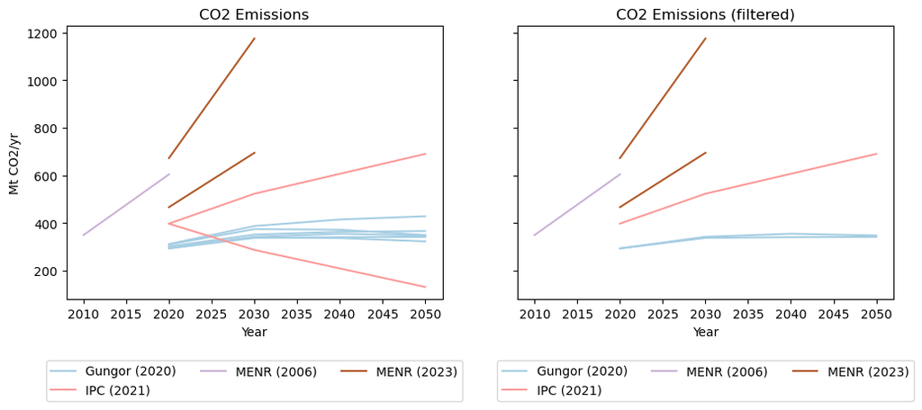

```python
%%capture --no-display
fig, ax = plt.subplots(1, 2, figsize=(12, 4), sharey=True)
df_co2 = df.filter(variable='Emissions|CO2')
df_co2.plot(ax=ax[0],title='CO2 Emissions',color='model',
            cmap=cmap, legend={"loc":"outside bottom"})
df_co2.filter(exclude=True).plot(ax=ax[1],title='CO2 Emissions (filtered)',color='model',
                                  cmap=cmap, legend={"loc":"outside bottom"})
```

# Categorization of scenarios by their fossil fuel shares

Although the fossil fuel reserves are modest in Turkey, their share in primary energy supply is above **80%** ([OECD Statistics](https://stats.oecd.org/fileview2.aspx?IDFile=0144c270-446f-48db-88f0-4ea1542244a5)). The expansion of **renewable energy** requires the electrification of hard-to-abate sectors such as industry, residential and transport. We can categorize the scenarios according to the share of `Primary Energy|Coal` by the end of the scenario horizon **2050**.

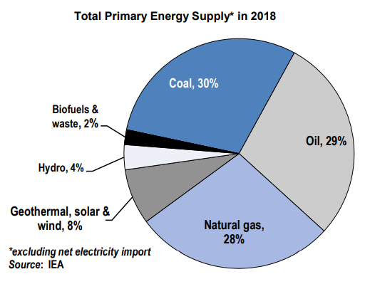

```python
df.categorize(
    "Share of coal", "below 30%",
    criteria={"Share of coal": {"up": 0.3}},
)
```

```
pyam.core - INFO: 3 scenarios categorized as `Share of coal: below 30%`
```

```python
df.meta
```

| model | scenario | exclude | Share of coal |
| --- | --- | --- | --- |
| Gungor (2020) | SSP1-Baseline-FIT | True | above 30% |
|  | SSP1-RCP2.6-FIT | True | above 30% |
|  | SSP2-Baseline-FIT | False | above 30% |
|  | SSP2-RCP2.6-FIT | False | above 30% |
|  | SSP3-Baseline-FIT | False | above 30% |
|  | SSP3-RCP3.4-FIT | False | above 30% |
| IPC (2020) | Alternative Scenario | False | below 30% |
|  | Reference Scenario | False | below 30% |
| IPC (2021) | Baseline Scenario | True | above 30% |
|  | Net-Zero Scenario | False | above 30% |
| MENR (2006) | Baseline Scenario | True | above 30% |
| MENR (2023) | Baseline Scenario | True | above 30% |
|  | CO2 Scenario | True | below 30% |
| TUBITAK (2012) | Baseline Scenario | False | above 30% |
|  | Optimistic Scenario | False | above 30% |
|  | Pessimistic Scenario | False | above 30% |

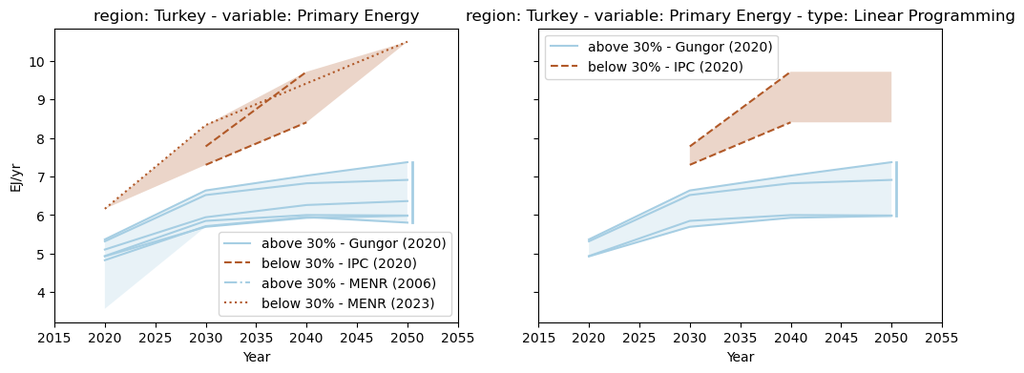

```python
%%capture --no-display
cmap = 'Paired'
fig, ax = plt.subplots(1, 2, figsize=(12, 4), sharey=True)
df_pe = df.filter(variable="Primary Energy", year=range(2020,2060))
df_pe.plot(ax=ax[0], color="Share of coal", linestyle="model", fill_between=True, final_ranges=True,
           cmap=cmap, legend={"loc":"best"}),
df_pe.filter(exclude=False).plot(ax=ax[1], color="Share of coal", linestyle="model", fill_between=True, final_ranges=True,
          cmap=cmap, legend={"loc":"best"})
```

## Energy flows for electricity generation with storage

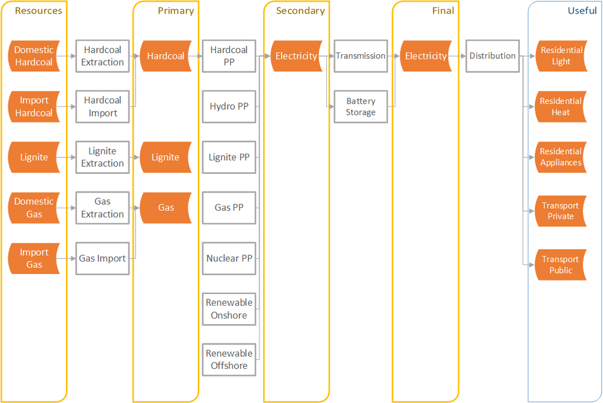

## Questions?

Take a look at our [GitHub repository](https://github.com/gorkemgungormetu/turkish_energy_and_climate_pathways.git)!